# HCAMP Lower Extremity

# Data Background

## Gender

| Gender | Total |
| --- | --- |
| Female | 93 |
| Male | 121 |
| NA | 19 |

## Age at Concussion

| Age | Total |
| --- | --- |
| 13.7 | 1 |
| 13.74 | 1 |
| 13.82 | 1 |
| 13.84 | 1 |
| 13.87 | 1 |
| 13.88 | 1 |
| 13.95 | 1 |
| 13.97 | 1 |
| 13.98 | 1 |
| 13.99 | 1 |

[output cut: 160 more lines]

## Age at Second Injury

| Age | Total |
| --- | --- |
| 13.74 | 1 |
| 13.9 | 1 |
| 14.03 | 1 |
| 14.15 | 1 |
| 14.17 | 1 |
| 14.23 | 1 |
| 14.24 | 2 |
| 14.25 | 1 |
| 14.26 | 2 |
| 14.3 | 1 |

[output cut: 162 more lines]

## League

| League | Total |
| --- | --- |
| BIIF | 16 |
| KIF | 14 |
| MIL | 44 |
| OIA | 159 |

## School

| League | School | Total |
| --- | --- | --- |
| MIL | Maui High School | 24 |
| OIA | Kalaheo High School | 23 |
| OIA | Mililani High School | 21 |
| OIA | Kalani High School | 14 |
| OIA | McKinley High School | 11 |
| OIA | Pearl City High School | 11 |
| OIA | Castle High School | 10 |
| BIIF | Konawaena High School | 9 |
| KIF | Kapaa High School | 8 |
| OIA | Aiea High School | 8 |

[output cut: 25 more lines]

## Sport Played Concussion Injury

| Sport | Total |
| --- | --- |
| Football | 88 |
| Women's Soccer | 25 |
| Softball | 14 |
| NA | 13 |
| Not team related | 12 |
| Women's Judo | 12 |
| Women's Volleyball | 10 |
| Cheerleading | 7 |
| Men's Judo | 7 |
| Men's Soccer | 7 |

[output cut: 8 more lines]

## Sport Level Concussion Injury

| Level | Total |
| --- | --- |
| Junior Varsity | 90 |
| Varsity | 86 |
| Varsity B | 1 |
| NA | 56 |

## Sport Played Lower Extremity Injury

| Sport | Total |
| --- | --- |
| Football | 77 |
| Women's Soccer | 30 |
| Not team related | 14 |
| NA | 13 |
| Women's Basketball | 12 |
| Cheerleading | 9 |
| Men's Basketball | 9 |
| Women's Judo | 9 |
| Women's Volleyball | 9 |
| Men's Wreslting | 8 |

[output cut: 11 more lines]

## Sport Level Lower Extremity Injury

| Level | Total |
| --- | --- |
| Junior Varsity | 71 |
| Varsity | 105 |
| Varsity B | 1 |
| NA | 56 |

# Second Injury Frequency

| Injury | Total |
| --- | --- |
| Ankle Achilles Inflammation | 1 |
| Ankle Achilles Tendon Contusion | 1 |
| Ankle Achilles Tendon Strain | 4 |
| Ankle Achilles Tendon Strain 1 Deg | 1 |
| Ankle Anterior Talo-Fibular Sprain | 15 |
| Ankle Anterior Talo-Fibular Sprain 1 Deg | 6 |
| Ankle Anterior Talo-Fibular Sprain 2 Deg | 4 |
| Ankle Anterior Talo-Fibular Sprain 3 Deg | 1 |
| Ankle Anterior Tibialis Strain | 1 |
| Ankle Anterior Tibio-Fibular Sprain 1 Deg | 1 |

[output cut: 110 more lines]

# Duration of Time Between Concussion and Lower Extremity Injury

## Gender

### Summary Table

Descriptive statistics of time between concussion and lower extremity injury by gender

| Gender | Mean | SD | Min | Max | Total |
| --- | --- | --- | --- | --- | --- |
| Female | 167.139784946237 | 126.89216505414 | 10 | 365 | 93 |
| Male | 163.619834710744 | 122.514302307822 | 3 | 360 | 121 |

### Box Plot

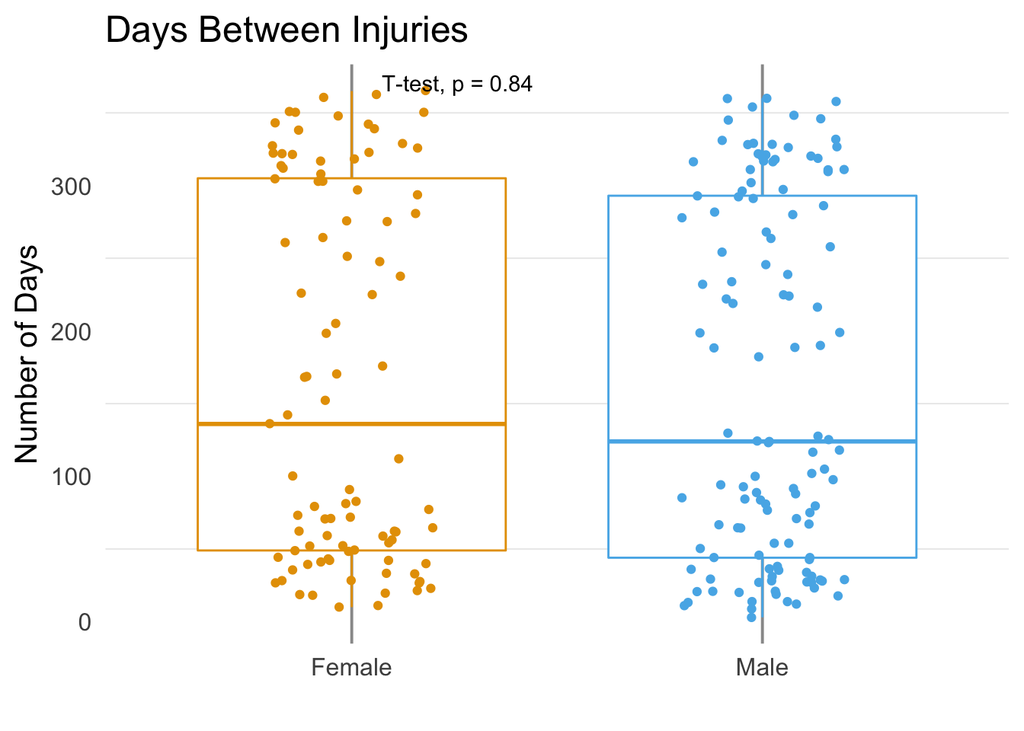

### *T*-Test Results

```
## # A tibble: 1 x 9
##   .y.                 group1 group2    n1    n2 statistic    df     p p.signif
##   <chr>               <chr>  <chr>  <int> <int>     <dbl> <dbl> <dbl> <chr>
## 1 days_between_injury Female Male      93   121     0.204  195. 0.838 ns
```

## Age

### Age Difference Distribution

To create plot, a new variable was created `age_difference` calculated as the difference between injury_2 age and injury_1 age. All differences are less than one year. The distribution is not normal with higher distribution at both tails.

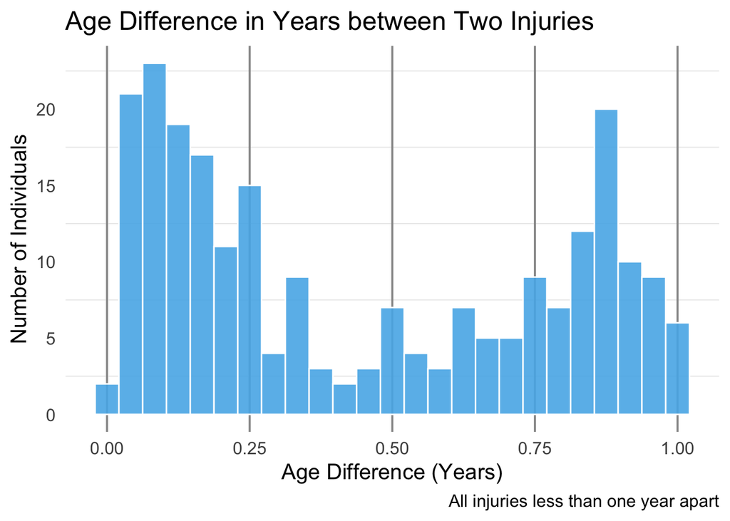

### Age 1 Total Distribution

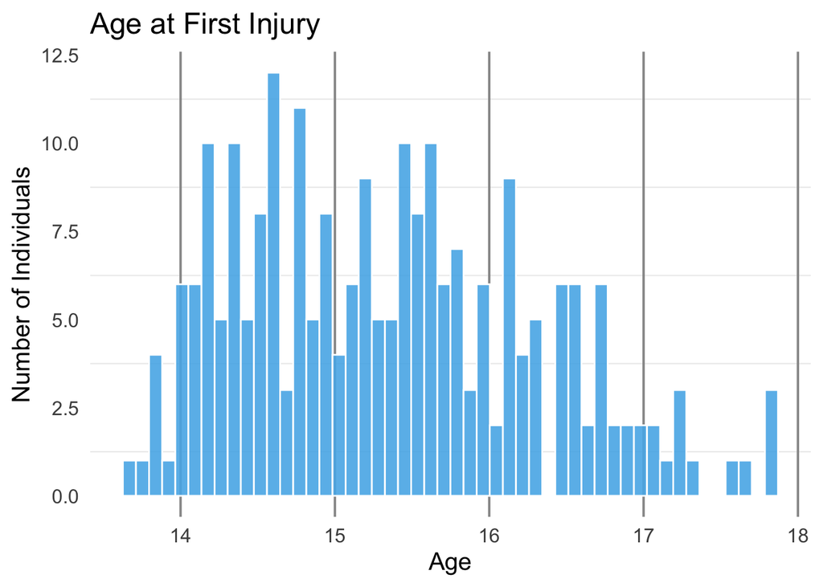

### Age 1 Distribution League

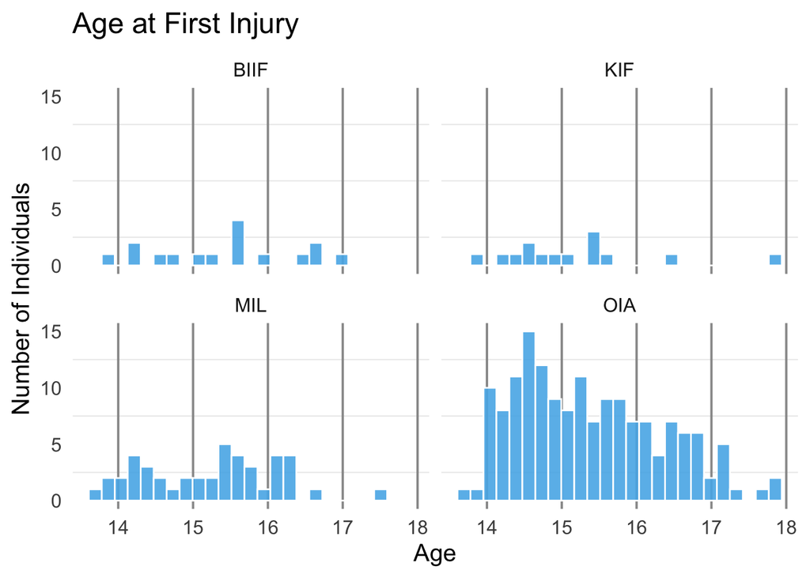

### Age 1 Distribution Gender

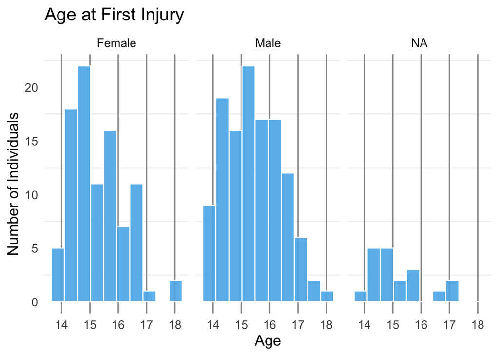

### Age 2 Total Distribution

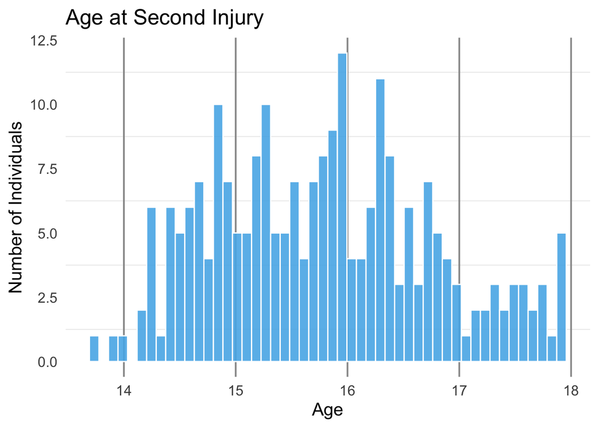

### Age 2 Distribution League

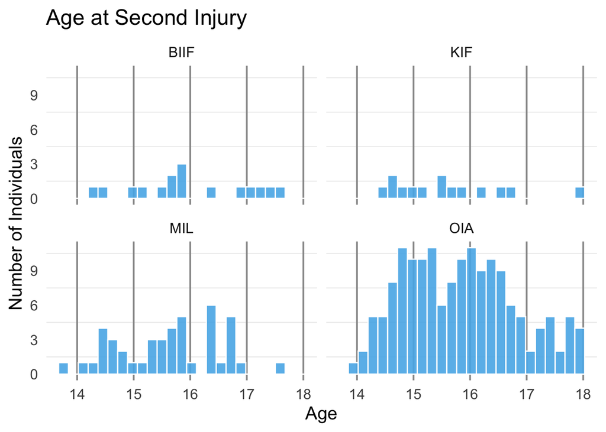

### Age 2 Distribution Gender

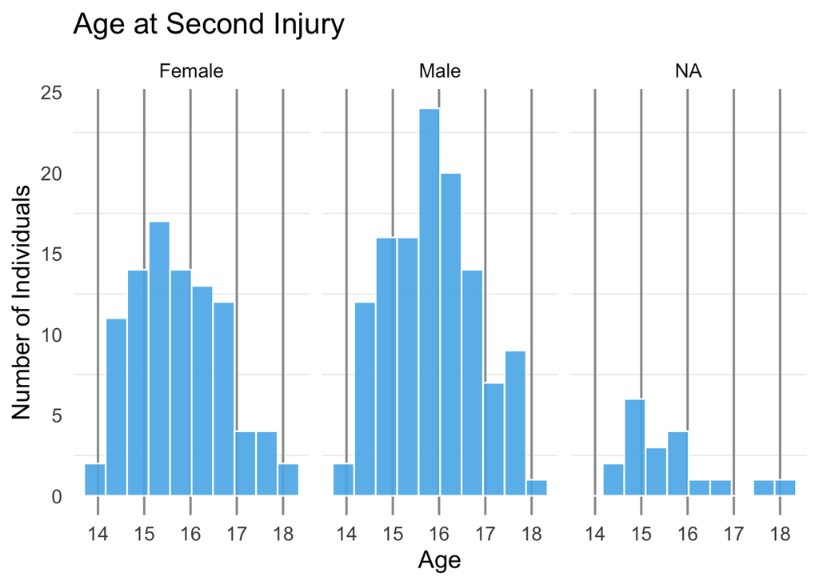

### Age Model

```
##
## Call:
## lm(formula = days_between_injury ~ age_2, data = age_diff)
##
## Residuals:
##     Min      1Q  Median      3Q     Max
## -218.66 -102.28  -30.33  113.82  222.00
##
## Coefficients:
##             Estimate Std. Error t value Pr(>|t|)
## (Intercept) -331.996    126.135  -2.632 0.009059 **
## age_2         31.339      7.973   3.931 0.000112 ***
## ---
## Signif. codes:  0 '***' 0.001 '**' 0.01 '*' 0.05 '.' 0.1 ' ' 1
##
## Residual standard error: 118.5 on 231 degrees of freedom
## Multiple R-squared:  0.06269,    Adjusted R-squared:  0.05863
## F-statistic: 15.45 on 1 and 231 DF,  p-value: 0.000112
```

## Sport

This section primarily explores the time between injuries for Football and Women’s Soccer as those are the two most common sports at time of concussion and lower extremity injury.

### Descriptive Statistics

Table displayed statistics of the number of days between injuries for individuals who sustained their injuries playing football or women’s soccer.

| Sport 1 | Sport 2 | Mean | SD | Min | Max | Total |
| --- | --- | --- | --- | --- | --- | --- |
| Football | Football | 142.469696969697 | 126.854394993384 | 9 | 360 | 66 |
| Women's Soccer | Women's Soccer | 206.8 | 143.672361184819 | 23 | 365 | 20 |

### Sport 2 Injury Type

Table displays the number of lower extremity injuries for individuals who played football and women’s soccer.

| Sport | Injury | Total |
| --- | --- | --- |
| Football | Ankle Anterior Talo-Fibular Sprain | 6 |
| Football | Ankle Lateral Sprain | 4 |
| Football | Knee Medial Collateral Sprain | 4 |
| Football | Knee Anterior Cruciate Sprain | 3 |
| Football | Ankle Anterior Talo-Fibular Sprain 1 Deg | 2 |
| Football | Fibula Fracture/Non-specific | 2 |
| Football | Groin Muscle Strain (non-specific) | 2 |
| Football | Knee Anterior Cruciate Sprain 3 Deg | 2 |
| Football | Knee Sprain (non-specific) | 2 |
| Football | Tibia Osgood/Schlatter's Syndrome | 2 |

[output cut: 55 more lines]

### Box Plot

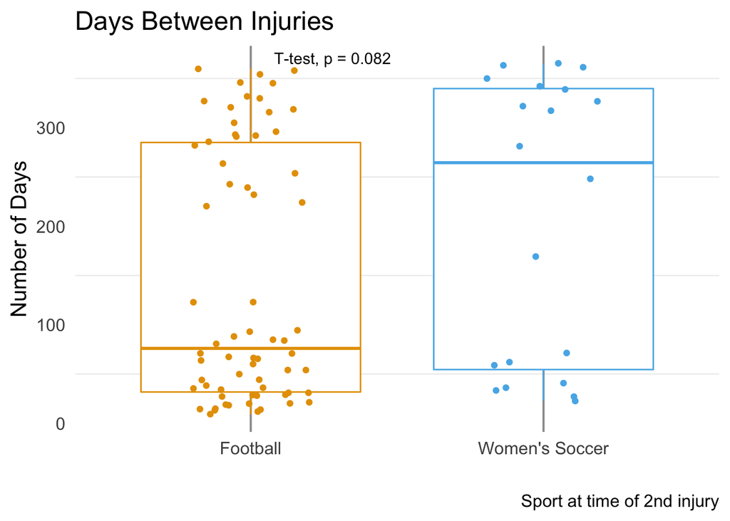

### *T*-Test Results

```
## # A tibble: 1 x 9
##   .y.            group1  group2         n1    n2 statistic    df      p p.signif
##   <chr>          <chr>   <chr>       <int> <int>     <dbl> <dbl>  <dbl> <chr>
## 1 days_between_… Footba… Women's So…    66    20     -1.80  28.6 0.0823 ns
```

## School

Schools with 20 or more individuals included.

### Descriptive Statistics

Table displayed statistics of the number of days between injuries for individuals who attend Kalaheo High School, Maui High School, and Mililani High Schol.

| School | Mean | SD | Min | Max | Total |
| --- | --- | --- | --- | --- | --- |
| Kalaheo High School | 128.478260869565 | 117.231654725015 | 13 | 348 | 23 |
| Maui High School | 122.166666666667 | 110.534537851167 | 11 | 338 | 24 |
| Mililani High School | 216.761904761905 | 133.165650511648 | 21 | 365 | 21 |

### Boxplot

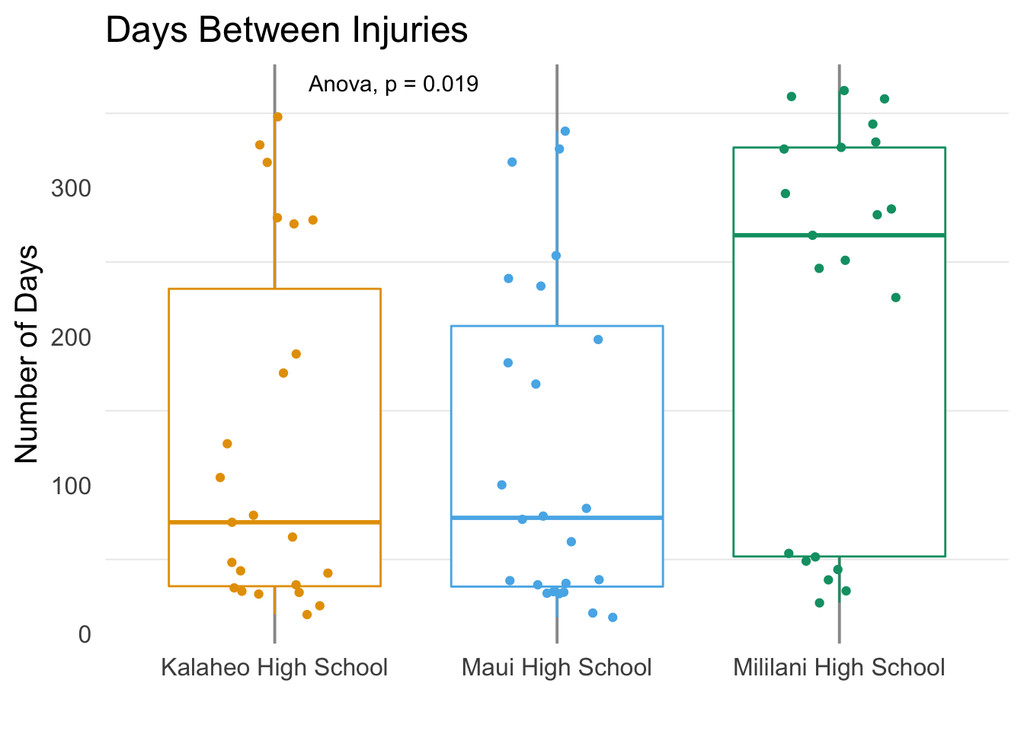

### Anova

The difference between the mean number of days between injury across the three high schools is significantly different. Students at Mililani High School, on average, experienced a much longer duration of time between injuries than students at Kalaheo High School and Maui High School.

```
##             Df Sum Sq Mean Sq F value Pr(>F)
## school_2     2 122006   61003   4.227 0.0188 *
## Residuals   65 938025   14431
## ---
## Signif. codes:  0 '***' 0.001 '**' 0.01 '*' 0.05 '.' 0.1 ' ' 1
```

### Pairwise Comparisons

```
##
##  Pairwise comparisons using t tests with pooled SD
##
## data:  school_analysis$days_between_injury and school_analysis$school_2
##
##                      Kalaheo High School Maui High School
## Maui High School     1.000               -
## Mililani High School 0.053               0.031
##
## P value adjustment method: bonferroni
```

## Level

Schools with 20 or more individuals included.

### Descriptive Statistics

Table displayed statistics of the number of days between injuries for the sport level at the time of the individuals’ lower extremity injury.

| Level | Mean | SD | Min | Max | Total |
| --- | --- | --- | --- | --- | --- |
| Varsity | 182.428571428571 | 125.395440441495 | 9 | 365 | 105 |

### Box Plot

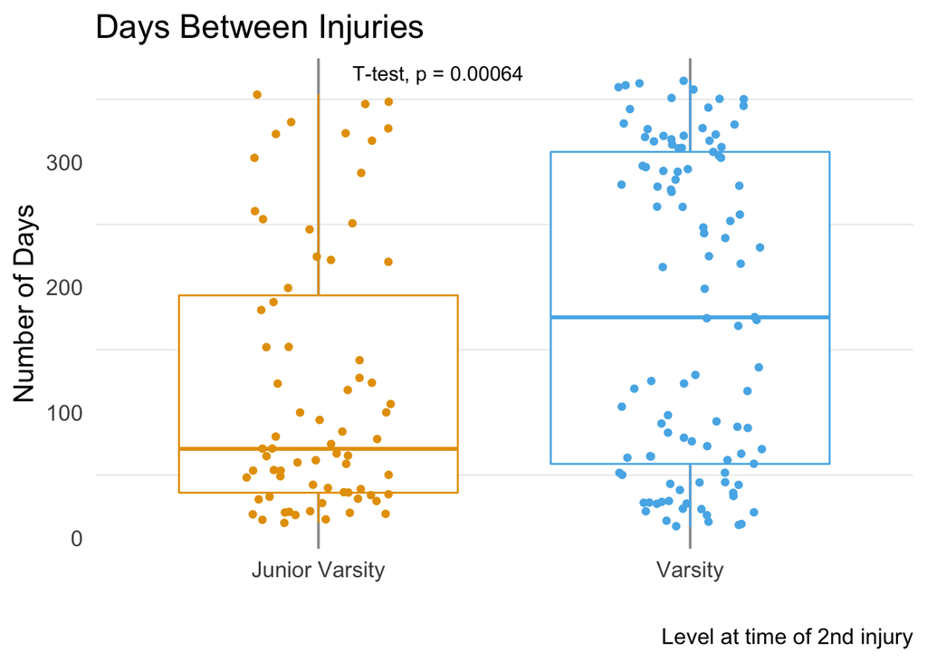

### *T*-Test Results

Individuals playing varsity sports at the time of second injury have a significantly different longer duration of time between injuries.

```
## # A tibble: 1 x 9
##   .y.            group1      group2    n1    n2 statistic    df       p p.signif
##   <chr>          <chr>       <chr>  <int> <int>     <dbl> <dbl>   <dbl> <chr>
## 1 days_between_… Junior Var… Varsi…    71   105     -3.48  165. 6.38e-4 ***
```

# Days Missed Following Injuries

One individual removed from sample because of missing information for days since both injuries reducing sample total to 232 individauls. The number of days missed post-concussion appears to have severe outliers?

## Descriptive Statistics

### Days Missed Following Concussion

| Injury | Mean | SD | Min | Max | Total |
| --- | --- | --- | --- | --- | --- |
| Head Concussion | 206.241379310345 | 661.439720801802 | 0 | 4393 | 232 |

### Days Missed Following Lower Extremity Injury

| Injury | Mean | SD | Min | Max | Total |
| --- | --- | --- | --- | --- | --- |
| Ankle Lateral Sprain | 35 | 73.2411541871554 | 0 | 291 | 16 |
| Ankle Anterior Talo-Fibular Sprain | 190.6 | 617.112261146335 | 0 | 2399 | 15 |
| Ankle Sprain (non-specific) | 150.266666666667 | 294.604933201511 | 0 | 1014 | 15 |
| Knee Medial Collateral Sprain | 31.25 | 34.6688415068714 | 6 | 102 | 8 |
| Knee Contusion | 409.857142857143 | 1079.53098281483 | 0 | 2858 | 7 |
| Ankle Anterior Talo-Fibular Sprain 1 Deg | 70 | 152.04999177902 | 1 | 380 | 6 |
| Knee Sprain (non-specific) | 10.5 | 8.98331787259028 | 0 | 27 | 6 |
| Knee Anterior Cruciate Sprain | 129.2 | 161.819961685819 | 8 | 329 | 5 |
| Knee Anterior Cruciate Sprain 3 Deg | 226.8 | 145.42592616174 | 37 | 408 | 5 |
| Ankle Achilles Tendon Strain | 9 | 7.74596669241483 | 2 | 20 | 4 |

[output cut: 110 more lines]

## *T*-Test Across Entire Sample

### Boxplot

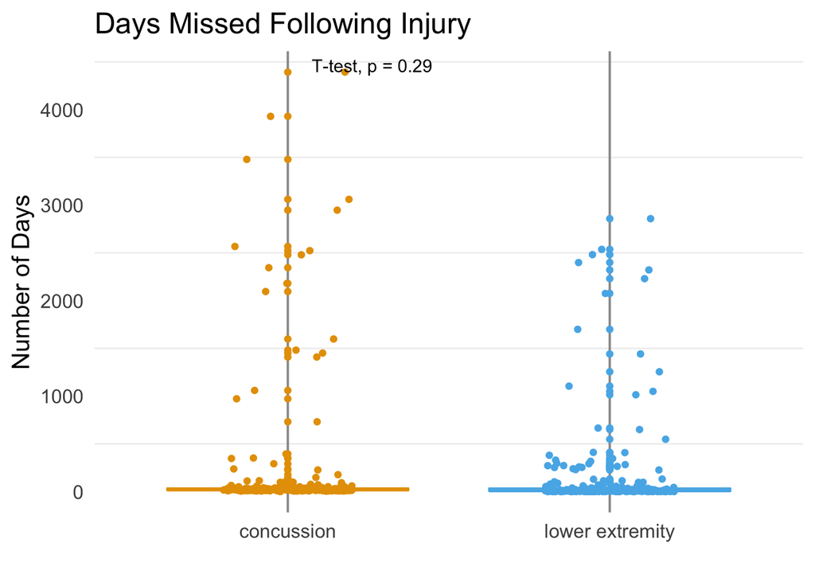

### Results

```
##
##  Paired t-test
##
## data:  days_missed_1 and days_missed_2
## t = 1.1298, df = 231, p-value = 0.2597
## alternative hypothesis: true difference in means is not equal to 0
## 95 percent confidence interval:
##  -41.55266 153.25955
## sample estimates:
## mean of the differences
##                55.85345
```

## Gender

### Days Missed Following Concussion

| Gender | Mean | SD | Min | Max | Total |
| --- | --- | --- | --- | --- | --- |
| Female | 181.869565217391 | 630.145791911321 | 0 | 4393 | 92 |
| Male | 206.322314049587 | 669.675794879831 | 4 | 3930 | 121 |
| NA | 323.736842105263 | 774.440073150005 | 7 | 2947 | 19 |

### Days Missed Following Lower Extremity Injury

| Gender | Mean | SD | Min | Max | Total |
| --- | --- | --- | --- | --- | --- |
| Female | 143.728260869565 | 389.000017041749 | 0 | 2482 | 92 |
| Male | 56.1652892561983 | 240.642208375403 | 0 | 2537 | 121 |
| NA | 782.684210526316 | 1038.05068665753 | 0 | 2858 | 19 |

### Concussion Box Plot

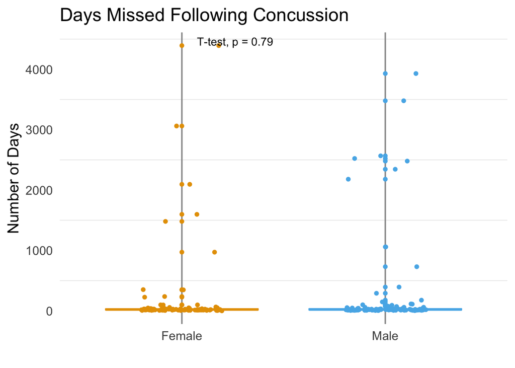

### Concussion *T*-Test Results

```
## # A tibble: 1 x 9
##   .y.                   group1 group2    n1    n2 statistic    df     p p.signif
##   <chr>                 <chr>  <chr>  <int> <int>     <dbl> <dbl> <dbl> <chr>
## 1 days_missed_concussi… Female Male      92   121    -0.273  202. 0.785 ns
```

### Lower Extremity Box Plot

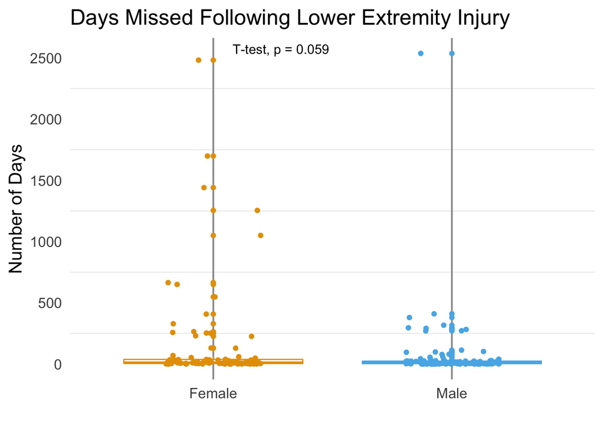

```
## # A tibble: 1 x 9
##   .y.                  group1 group2    n1    n2 statistic    df      p p.signif
##   <chr>                <chr>  <chr>  <int> <int>     <dbl> <dbl>  <dbl> <chr>
## 1 days_missed_lower_e… Female Male      92   121      1.90  143. 0.0594 ns
```